# Cx4073 : Assignment 2

Edwin Khoo Ding Neng

U1721633J

### Targeted Marketing for Car Insurance

Suppose you the Data Scientist in a small Car Insurance company, and you want to judge if the Customers will accept or reject a new Insurance product that the company is going to launch. Your company did a pilot with 9000 customers and obtained the corresponding dataset. The classification goal is to learn from this pilot, and predict if a targeted customer will respond *Yes* to the offer. Your company also wants to identify the top three variables that may affect the response of the customers, and they also want to know how to increase the chances for the customers to respond *Yes* to the offered Insurance product.

### Analysis of Marketing Data

Import the CSV data file `assign2_MarketData.csv` for analysis, and quickly check the structure of the data.

```r
marketData <- read.csv("assign2_MarketData.csv", header = TRUE)
str(marketData)
```

```
## 'data.frame':    9000 obs. of  24 variables:
##  $ Customer                     : Factor w/ 9000 levels "AA10041","AA11235",..: 2035 721 1645 8505 6230 1997 8610 4163 338 5607 ...
##  $ State                        : Factor w/ 5 levels "Arizona","California",..: 4 2 2 2 4 3 1 2 2 2 ...
##  $ Customer.Lifetime.Value      : num  24179 5462 4890 7433 2237 ...
##  $ Coverage                     : Factor w/ 3 levels "Basic","Extended",..: 2 1 1 1 1 1 1 2 1 1 ...
##  $ Education                    : Factor w/ 5 levels "Bachelor","College",..: 2 4 1 2 2 3 4 4 1 1 ...
##  $ Effective.To.Date            : Factor w/ 59 levels "1/1/11","1/10/11",..: 18 29 57 7 54 31 30 31 23 33 ...
##  $ EmploymentStatus             : Factor w/ 5 levels "Disabled","Employed",..: 2 2 2 2 5 1 5 2 5 5 ...
##  $ Gender                       : Factor w/ 2 levels "F","M": 2 1 1 1 1 1 2 2 1 1 ...
##  $ Income                       : int  43704 39626 46819 58839 0 25703 0 44379 0 0 ...
##  $ Location.Code                : Factor w/ 3 levels "Rural","Suburban",..: 2 2 3 1 2 2 2 2 2 2 ...
##  $ Marital.Status               : Factor w/ 3 levels "Divorced","Married",..: 2 2 1 3 2 2 3 2 3 3 ...
##  $ Monthly.Premium.Auto         : int  201 69 62 65 61 62 107 83 101 116 ...
##  $ Months.Since.Last.Claim      : int  29 23 15 4 19 4 22 10 10 12 ...
##  $ Months.Since.Policy.Inception: int  67 0 0 65 44 64 96 12 48 76 ...
##  $ Number.of.Open.Complaints    : int  0 0 0 3 0 0 0 1 0 1 ...
##  $ Number.of.Policies           : int  2 3 5 2 1 1 4 8 2 2 ...
##  $ Policy.Type                  : Factor w/ 3 levels "Corporate Auto",..: 2 2 2 2 2 2 2 3 2 2 ...
##  $ Policy                       : Factor w/ 9 levels "Corporate L1",..: 6 6 5 6 5 6 5 9 6 6 ...
##  $ Renew.Offer.Type             : Factor w/ 4 levels "Offer1","Offer2",..: 1 2 1 1 3 1 4 2 1 1 ...
##  $ Sales.Channel                : Factor w/ 4 levels "Agent","Branch",..: 2 1 1 3 1 3 4 3 1 1 ...
##  $ Total.Claim.Amount           : num  1064 486 158 19 293 ...
##  $ Vehicle.Class                : Factor w/ 6 levels "Four-Door Car",..: 3 1 1 6 1 1 5 1 5 5 ...
##  $ Vehicle.Size                 : Factor w/ 3 levels "Large","Medsize",..: 2 1 1 2 3 3 2 2 2 3 ...
##  $ Response                     : Factor w/ 2 levels "No","Yes": 1 1 1 1 1 1 1 1 1 1 ...
```

The goal is to predict the response variable `Response` for each person – that is, whether a person would accept the new *Insurance Product* being offered by your company. Before you do that, tag the variables under **Demographic Profile** or **Insurance Profile** of the customers, as per your understanding. Justify why the variables belong to Demographic or Insurance profile of a customer, if required.

#### Problem 1

Build an optimal tree-based classification model for `Response` vs just the **Insurance Profile** of a customer. Check the relevant accuracy parameters of your model, and use it to predict `Response` in the `assign2_MarketPred.csv`.

- Identify the *top three* important variables in this case.
- Why are they important? Justify in terms of the Pilot data.
- How would you influence `Response` using these variables?

#### Problem 2

Build an optimal tree-based classification model for `Response` vs both **Demographic Profile** and **Insurance Profile** of a customer. Check the relevant accuracy parameters of your model, and use it to predict `Response` in the `assign2_MarketPred.csv`.

- Identify the *top three* important variables in this case.
- Why are they important? Justify in terms of the Pilot data.
- How would you influence `Response` using these variables?

### Exploration of Marketing Data

Heads and tails displays the first and last few rows of the dataset, providing a general idea of the the variables values and their magnitudes.

```r
head(marketData)
```

```
##   Customer      State Customer.Lifetime.Value Coverage            Education
## 1  FX48006     Oregon               24178.685 Extended              College
## 2  CE72177 California                5461.549    Basic High School or Below
## 3  EW68125 California                4889.765    Basic             Bachelor
## 4  YO62357 California                7432.857    Basic              College
## 5  SC78905     Oregon                2237.348    Basic              College
## 6  FU43761     Nevada                2435.620    Basic               Doctor
##   Effective.To.Date EmploymentStatus Gender Income Location.Code Marital.Status
## 1           1/25/11         Employed      M  43704      Suburban        Married
## 2            1/7/11         Employed      F  39626      Suburban        Married
## 3            2/7/11         Employed      F  46819         Urban       Divorced
## 4           1/15/11         Employed      F  58839         Rural         Single
## 5            2/4/11       Unemployed      F      0      Suburban        Married
## 6            1/9/11         Disabled      F  25703      Suburban        Married
##   Monthly.Premium.Auto Months.Since.Last.Claim Months.Since.Policy.Inception
```

[output cut: 27 more lines]

```r
tail(marketData)
```

```
##      Customer      State Customer.Lifetime.Value Coverage            Education
## 8995  XR70252 California                4788.933    Basic High School or Below
## 8996  XZ40716 California                8054.982  Premium High School or Below
## 8997  CR48975 Washington               24084.535    Basic High School or Below
## 8998  RO25639     Nevada                5442.744    Basic               Doctor
## 8999  XF60649 California                7452.939    Basic             Bachelor
## 9000  LM69036     Oregon               14050.174    Basic               Master
##      Effective.To.Date EmploymentStatus Gender Income Location.Code
## 8995           2/22/11       Unemployed      F      0      Suburban
## 8996           1/18/11         Employed      F  75531      Suburban
## 8997            2/2/11         Employed      M  65196      Suburban
## 8998            2/3/11         Employed      F  25884         Urban
## 8999            1/4/11       Unemployed      F      0      Suburban
## 9000           1/10/11       Unemployed      M      0      Suburban
##      Marital.Status Monthly.Premium.Auto Months.Since.Last.Claim
```

[output cut: 27 more lines]

Summary statistics for all variables

```r
summary(marketData)
```

```
##     Customer           State      Customer.Lifetime.Value     Coverage
##  AA10041:   1   Arizona   :1679   Min.   : 1898           Basic   :5495
##  AA11235:   1   California:3100   1st Qu.: 3997           Extended:2691
##  AA16582:   1   Nevada    : 871   Median : 5780           Premium : 814
##  AA30683:   1   Oregon    :2567   Mean   : 8002
##  AA34092:   1   Washington: 783   3rd Qu.: 8955
##  AA35519:   1                     Max.   :83325
##  (Other):8994
##                 Education    Effective.To.Date      EmploymentStatus Gender
##  Bachelor            :2708   1/10/11: 191      Disabled     : 402    F:4587
##  College             :2641   1/27/11: 190      Employed     :5617    M:4413
##  Doctor              : 334   2/14/11: 185      Medical Leave: 422
##  High School or Below:2580   1/26/11: 178      Retired      : 279
##  Master              : 737   1/31/11: 176      Unemployed   :2280
##                              1/3/11 : 175
##                              (Other):7905
##      Income       Location.Code   Marital.Status Monthly.Premium.Auto
##  Min.   :    0   Rural   :1755   Divorced:1349   Min.   : 61.00
##  1st Qu.:    0   Suburban:5690   Married :5221   1st Qu.: 68.00
##  Median :33922   Urban   :1555   Single  :2430   Median : 83.00
##  Mean   :37698                                   Mean   : 93.21
##  3rd Qu.:62399                                   3rd Qu.:109.00
##  Max.   :99981                                   Max.   :298.00
##
##  Months.Since.Last.Claim Months.Since.Policy.Inception
##  Min.   : 0.0            Min.   : 0.00
##  1st Qu.: 6.0            1st Qu.:24.00
##  Median :14.0            Median :48.00
##  Mean   :15.1            Mean   :48.05
##  3rd Qu.:23.0            3rd Qu.:71.00
##  Max.   :35.0            Max.   :99.00
##
##  Number.of.Open.Complaints Number.of.Policies         Policy.Type
##  Min.   :0.0000            Min.   :1.000      Corporate Auto:1940
##  1st Qu.:0.0000            1st Qu.:1.000      Personal Auto :6685
##  Median :0.0000            Median :2.000      Special Auto  : 375
##  Mean   :0.3837            Mean   :2.966
##  3rd Qu.:0.0000            3rd Qu.:4.000
##  Max.   :5.0000            Max.   :9.000
##
##           Policy     Renew.Offer.Type     Sales.Channel  Total.Claim.Amount
##  Personal L3 :3373   Offer1:3690      Agent      :3427   Min.   :   0.099
##  Personal L2 :2086   Offer2:2888      Branch     :2529   1st Qu.: 271.059
##  Personal L1 :1226   Offer3:1411      Call Center:1739   Median : 382.565
##  Corporate L3: 999   Offer4:1011      Web        :1305   Mean   : 433.659
##  Corporate L2: 588                                       3rd Qu.: 547.200
##  Corporate L1: 353                                       Max.   :2893.240
##  (Other)     : 375
##        Vehicle.Class   Vehicle.Size  Response
##  Four-Door Car:4557   Large  : 931   No :7713
##  Luxury Car   : 160   Medsize:6330   Yes:1287
##  Luxury SUV   : 182   Small  :1739
##  Sports Car   : 473
##  SUV          :1774
##  Two-Door Car :1854
##
```

Illustrates distribustion of target `Response` in dataset.

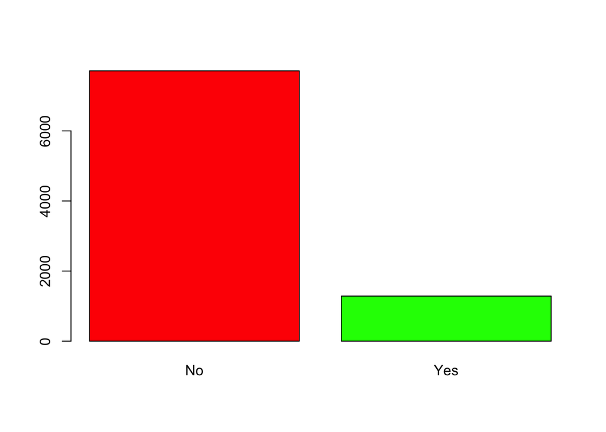

```r
cols <- c("red","green")
plot(marketData$Response, col = cols)
```

It can be seen that the amount of `Response` are not evenly distributed and thus appropriate sampling is required in the model building.

Ordering and simplifing the `Effective.to.Date` into the months. Its observed that the data only contians January and Febuary so They are leveled accordingly. So new `Effective.to.Date` contains two level “Jan” and “Feb”.

```r
#install.packages("lubridate",repos="http://cran.us.r-project.org")
library(lubridate)
a<-as.character(marketData$Effective.To.Date)
b<-as.Date.character(a, format = "%m/%d/%y")

#transform data to month names
marketData$Effective.To.Date <-month(b, label = TRUE)
marketData$Effective.To.Date <- factor(marketData$Effective.To.Date,
                             levels = c("Jan","Feb"),ordered = FALSE)
str(marketData)
```

```
## 'data.frame':    9000 obs. of  24 variables:
##  $ Customer                     : Factor w/ 9000 levels "AA10041","AA11235",..: 2035 721 1645 8505 6230 1997 8610 4163 338 5607 ...
##  $ State                        : Factor w/ 5 levels "Arizona","California",..: 4 2 2 2 4 3 1 2 2 2 ...
##  $ Customer.Lifetime.Value      : num  24179 5462 4890 7433 2237 ...
##  $ Coverage                     : Factor w/ 3 levels "Basic","Extended",..: 2 1 1 1 1 1 1 2 1 1 ...
##  $ Education                    : Factor w/ 5 levels "Bachelor","College",..: 2 4 1 2 2 3 4 4 1 1 ...
##  $ Effective.To.Date            : Factor w/ 2 levels "Jan","Feb": 1 1 2 1 2 1 1 1 1 2 ...
##  $ EmploymentStatus             : Factor w/ 5 levels "Disabled","Employed",..: 2 2 2 2 5 1 5 2 5 5 ...
##  $ Gender                       : Factor w/ 2 levels "F","M": 2 1 1 1 1 1 2 2 1 1 ...
##  $ Income                       : int  43704 39626 46819 58839 0 25703 0 44379 0 0 ...
##  $ Location.Code                : Factor w/ 3 levels "Rural","Suburban",..: 2 2 3 1 2 2 2 2 2 2 ...
##  $ Marital.Status               : Factor w/ 3 levels "Divorced","Married",..: 2 2 1 3 2 2 3 2 3 3 ...
##  $ Monthly.Premium.Auto         : int  201 69 62 65 61 62 107 83 101 116 ...
##  $ Months.Since.Last.Claim      : int  29 23 15 4 19 4 22 10 10 12 ...
##  $ Months.Since.Policy.Inception: int  67 0 0 65 44 64 96 12 48 76 ...
##  $ Number.of.Open.Complaints    : int  0 0 0 3 0 0 0 1 0 1 ...
##  $ Number.of.Policies           : int  2 3 5 2 1 1 4 8 2 2 ...
##  $ Policy.Type                  : Factor w/ 3 levels "Corporate Auto",..: 2 2 2 2 2 2 2 3 2 2 ...
##  $ Policy                       : Factor w/ 9 levels "Corporate L1",..: 6 6 5 6 5 6 5 9 6 6 ...
##  $ Renew.Offer.Type             : Factor w/ 4 levels "Offer1","Offer2",..: 1 2 1 1 3 1 4 2 1 1 ...
##  $ Sales.Channel                : Factor w/ 4 levels "Agent","Branch",..: 2 1 1 3 1 3 4 3 1 1 ...
##  $ Total.Claim.Amount           : num  1064 486 158 19 293 ...
##  $ Vehicle.Class                : Factor w/ 6 levels "Four-Door Car",..: 3 1 1 6 1 1 5 1 5 5 ...
##  $ Vehicle.Size                 : Factor w/ 3 levels "Large","Medsize",..: 2 1 1 2 3 3 2 2 2 3 ...
##  $ Response                     : Factor w/ 2 levels "No","Yes": 1 1 1 1 1 1 1 1 1 1 ...
```

Firstly, `Customer` was not included in exploration as the data is a randomly generated ID which will show no pattern or trend when plotted against `Response`. Explore the `Response` vs selected variables in the **Insurance Profile** of a customer. Variables in **Insurance Profile**: 1. Customer.Lifetime.Value 2. Coverage 3. Effective.To.Date 4. Monthly.Premium.Auto 5. Months.Since.Last.Claim 6. Months.Since.Policy.Inception 7. Number.of.Policies 8. Policy.Type 9. Policy 10. Renew.Offer.Type 11. Total.Claim.Amount

All of the above variables are chosen as **Insurance Profile** of a customer. They are all details in which a customer insurance profile should include as they are details of the policies itself and such exisiting records of policies with the insurance companies. Exploration plots are only done for those significant features.

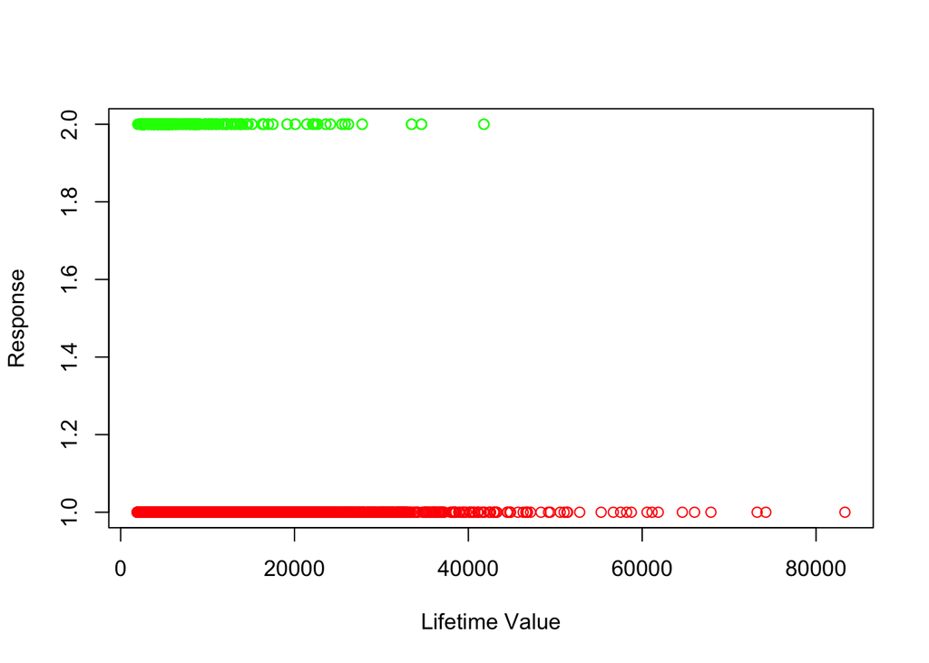

```r
plot(marketData$Customer.Lifetime.Value, marketData$Response, ylab="Response", xlab="Lifetime Value", col = cols[as.numeric(marketData$Response)])
```

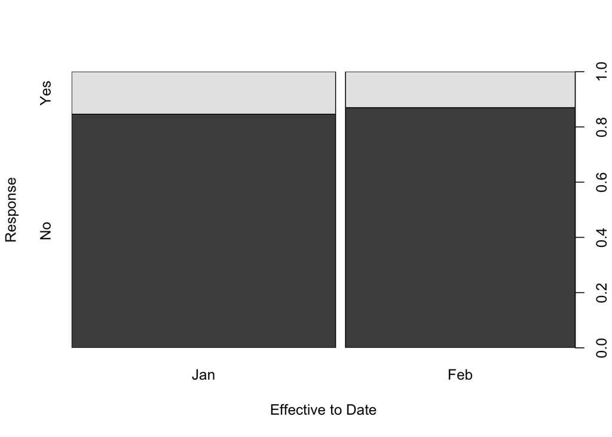

```r
plot(marketData$Effective.To.Date, marketData$Response, ylab="Response", xlab="Effective to Date")
```

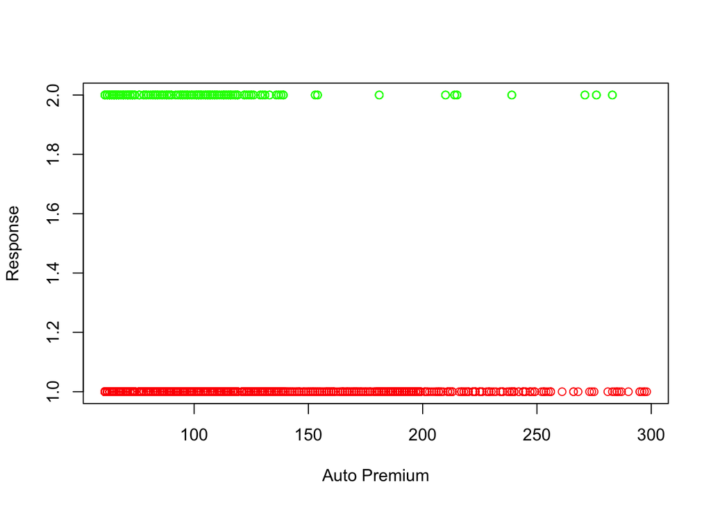

```r
plot(marketData$Monthly.Premium.Auto, marketData$Response, ylab="Response", xlab="Auto Premium", col = cols[as.numeric(marketData$Response)])
```

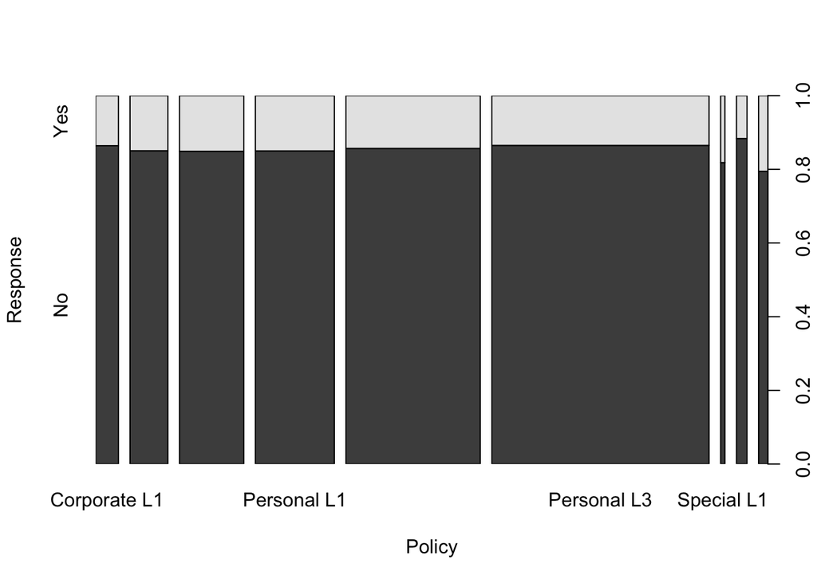

```r
plot(marketData$Policy, marketData$Response, ylab="Response", xlab="Policy")
```

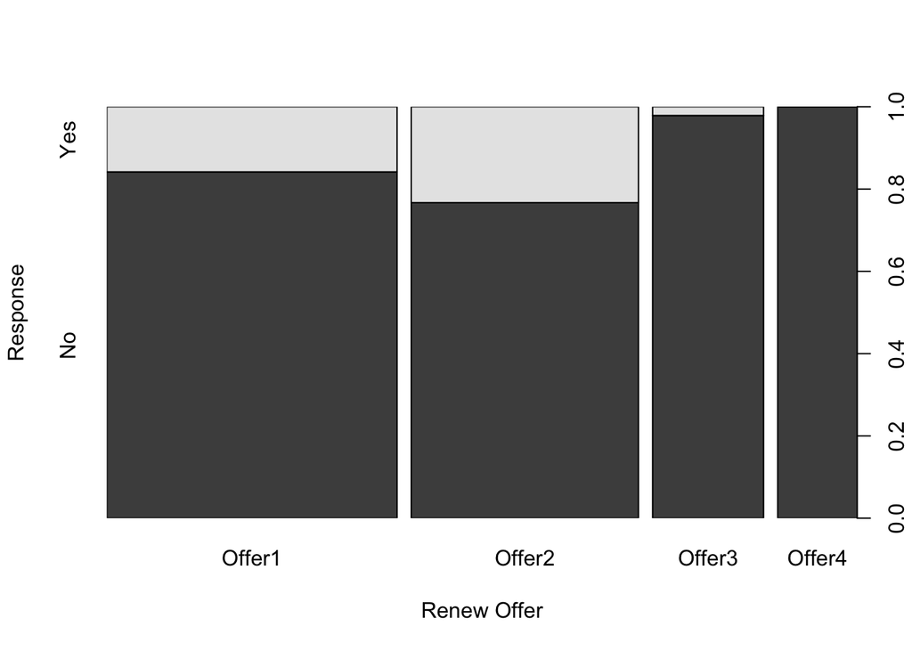

```r
plot(marketData$Renew.Offer.Type, marketData$Response, ylab="Response", xlab="Renew Offer")
```

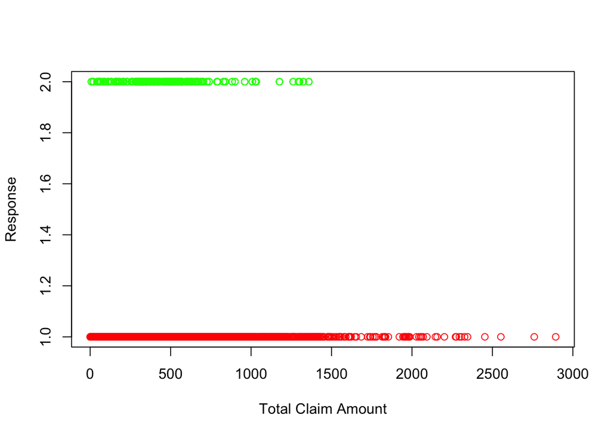

```r
plot(marketData$Total.Claim.Amount, marketData$Response, ylab="Response", xlab="Total Claim Amount", col = cols[as.numeric(marketData$Response)])
```

The list below shows variables with signifance and its observered trends and behavious with target `Response`. Lifetime Value: When value increases beyond a threshold of about 40000, all `Response` becomes “No”. Effective to Date: January has a slighlt higher “Yes” `Response` than Febuary. Auto Premium: When value increases beyong threshold of about 150, the `Response` concentrates towards “No”. Policy: There is a noticable difference in the “Yes” “No” `Response` between the different Level of the Special policies. Renew Offer: The Offer2 renew offers shows the most “Yes” `Response` distribution, while Offer 3 & 4 reported almost all `Response` “No”. Total Claim Amount: When value increases beyond a threshold of about 1500, all `Response` becomes “No”.

Explore the `Response` vs selected variables in the **Demographic Profile** of a customer. Variables in **Demograpgic Profile**: 1. State 2. Education 3. EmploymentStatus 4. Gender 5. Income 6. Location.Code 7. Marital.Status 8. Number.of.Open.Complaints 9. Sales.Channel 10. Vehicle.Class 11. Vehicle.Size

All of the above variables are chosen as **Demographic Profile** of a customer. They are all details in which a customer background information of a customer profile should include. Exploration plots are only done for those significant features.

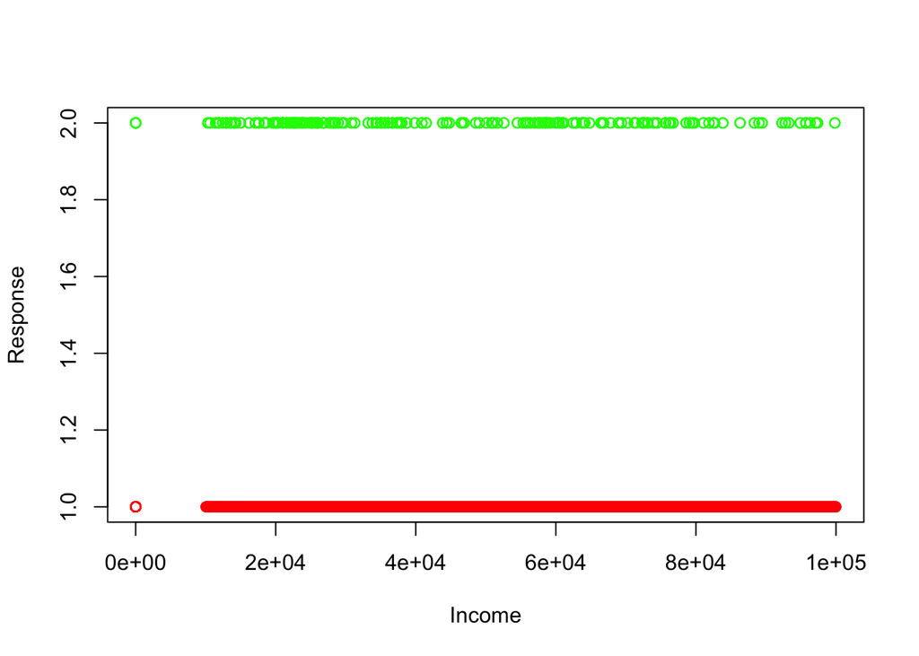

```r
plot(marketData$Income, marketData$Response, ylab="Response", xlab="Income", col = cols[as.numeric(marketData$Response)])
```

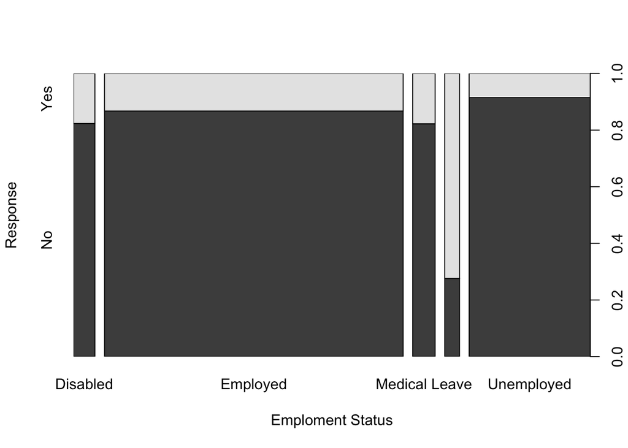

```r
plot(marketData$EmploymentStatus, marketData$Response, ylab="Response", xlab="Emploment Status")
```

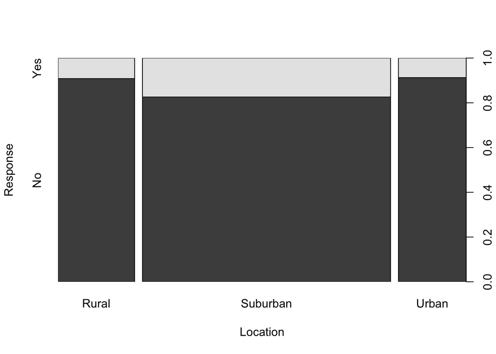

```r
plot(marketData$Location.Code, marketData$Response, ylab="Response", xlab="Location")
```

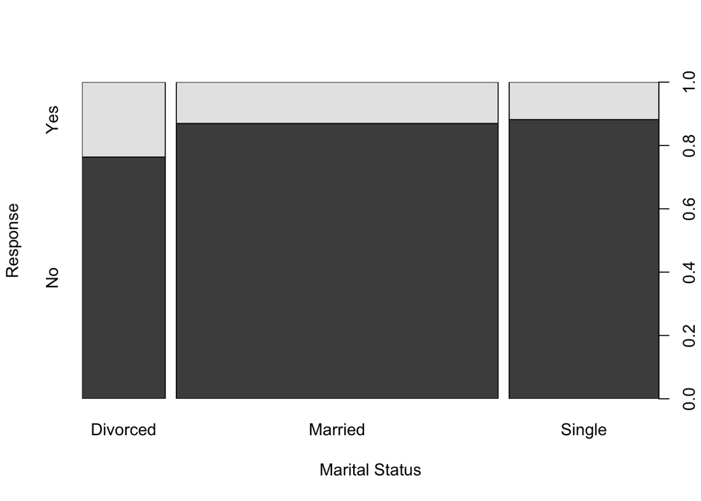

```r
plot(marketData$Marital.Status, marketData$Response, ylab="Response", xlab="Marital Status")
```

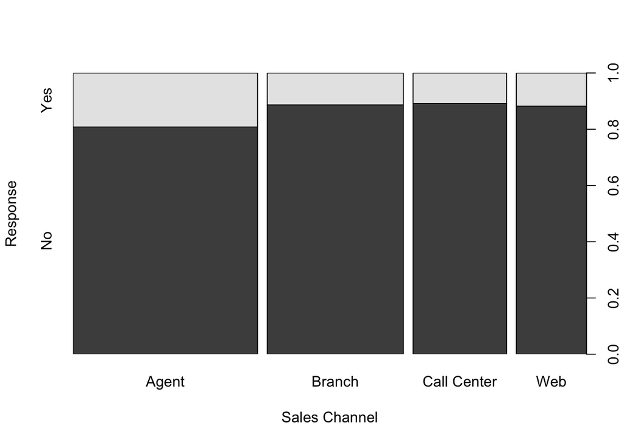

```r
plot(marketData$Sales.Channel, marketData$Response, ylab="Response", xlab="Sales Channel")
```

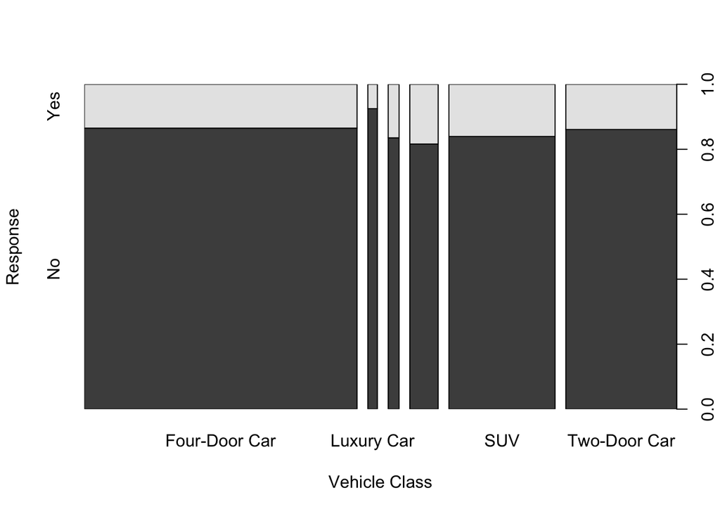

```r
plot(marketData$Vehicle.Class, marketData$Response, ylab="Response", xlab="Vehicle Class")
```

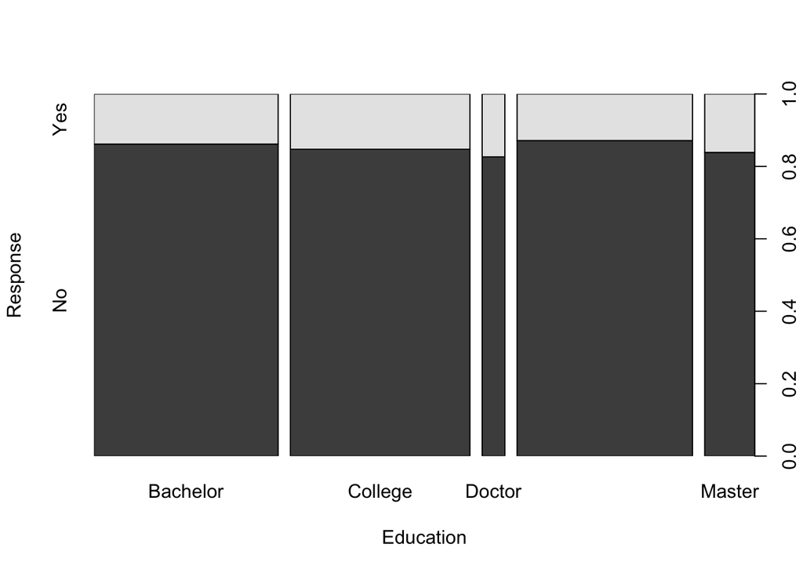

```r
plot(marketData$Education, marketData$Response, ylab="Response", xlab="Education")
```

The list below shows variables with signifance and its observered trends and behavious with target `Response`. Income: There is a some sparity in the Yes `Response` at certian values of Income. Employment Status: Retired Customer has a high percentage of having a “Yes” `Response`. Location: Customer staying in the suburban has a higher probability in having a “Yes” `Response`. Marital Status: Divorcee has a higher probability in having a “Yes” `Response`. Sales Channel: Customer approached by an agent has a higher probability in having a “Yes” `Response`. Vehicle Class: Customer driving a luxury car has the highest probability of having a “No” `Response`. Education: Highly educated CUstomer has a higher chance of having a “Yes” `Response`. —

### Model Building

Split into Train and Validation sets Training Set : Validation Set = 70 : 30 (random) Since in the above exploration it is noted that the data is imbalanced so SMOTE algorithm will be applied to balance the data by oversampling the minority class.

```r
set.seed(13)
train <- sample(nrow(marketData), 0.7*nrow(marketData), replace = FALSE)
marketTrain <- marketData[train,]
marketValid <- marketData[-train,]
#install.packages("DMwR")
table(marketTrain$Respose)
```

```
## < table of extent 0 >
```

```r
library(DMwR)
train_smote <- SMOTE(Response ~., marketTrain, perc.over = 500, perc.under = 120)
table(train_smote$Response)
```

```
##
##   No  Yes
## 5412 5412
```

```r
summary(train_smote)
```

```
##     Customer            State      Customer.Lifetime.Value     Coverage
##  OQ82364:   38   Arizona   :2110   Min.   : 1898           Basic   :6413
##  GJ99406:   33   California:3593   1st Qu.: 4203           Extended:3460
##  VJ64329:   33   Nevada    :1136   Median : 6054           Premium : 951
##  TR81766:   31   Oregon    :3124   Mean   : 7969
##  CR92802:   30   Washington: 861   3rd Qu.: 9121
##  EV95033:   30                     Max.   :66026
##  (Other):10629
##                 Education    Effective.To.Date      EmploymentStatus Gender
##  Bachelor            :3020   Jan:5706          Disabled     : 686    F:5682
##  College             :3220   Feb:5118          Employed     :6447    M:5142
##  Doctor              : 419                     Medical Leave: 522
##  High School or Below:3053                     Retired      : 996
##  Master              :1112                     Unemployed   :2173
##
##
##      Income       Location.Code   Marital.Status Monthly.Premium.Auto
##  Min.   :    0   Rural   :2047   Divorced:2244   Min.   : 61.00
##  1st Qu.:18538   Suburban:7174   Married :5760   1st Qu.: 70.59
##  Median :34484   Urban   :1603   Single  :2820   Median : 86.08
##  Mean   :37772                                   Mean   : 92.62
##  3rd Qu.:57588                                   3rd Qu.:105.00
##  Max.   :99981                                   Max.   :298.00
##
##  Months.Since.Last.Claim Months.Since.Policy.Inception
##  Min.   : 0.000          Min.   : 0.00
##  1st Qu.: 6.767          1st Qu.:28.00
##  Median :13.000          Median :50.00
##  Mean   :14.542          Mean   :48.72
##  3rd Qu.:22.000          3rd Qu.:69.00
##  Max.   :35.000          Max.   :99.00
##
##  Number.of.Open.Complaints Number.of.Policies         Policy.Type
##  Min.   :0.0000            Min.   :1.000      Corporate Auto:2982
##  1st Qu.:0.0000            1st Qu.:1.000      Personal Auto :7017
##  Median :0.0000            Median :2.000      Special Auto  : 825
##  Mean   :0.3605            Mean   :2.905
##  3rd Qu.:0.1312            3rd Qu.:3.874
##  Max.   :5.0000            Max.   :9.000
##
##           Policy     Renew.Offer.Type     Sales.Channel  Total.Claim.Amount
##  Personal L3 :3507   Offer1:4720      Agent      :4181   Min.   :   0.3821
##  Personal L2 :2251   Offer2:4282      Branch     :2968   1st Qu.: 282.5244
##  Corporate L3:1545   Offer3:1132      Call Center:2059   Median : 390.6013
##  Personal L1 :1283   Offer4: 690      Web        :1616   Mean   : 421.2815
##  Corporate L2: 995                                       3rd Qu.: 521.5239
##  Corporate L1: 462                                       Max.   :2893.2397
##  (Other)     : 781
##        Vehicle.Class   Vehicle.Size  Response
##  Four-Door Car:5344   Large  :1591   No :5412
##  Luxury Car   : 131   Medsize:7056   Yes:5412
##  Luxury SUV   : 189   Small  :2177
##  Sports Car   : 561
##  SUV          :2183
##  Two-Door Car :2416
##
```

The balancing ensures the model build based on the dataset will be able to predict both classes without biased accuracy to either one class.

Build Forest Model on **Insurance profile** of a customer (Problem 1)

```r
library(randomForest)
# Build a random forest model on Insurance profile
rfFit1 <- randomForest(Response ~ .- Customer - State - Education - EmploymentStatus - Gender
                      - Income - Location.Code - Marital.Status - Number.of.Open.Complaints - Sales.Channel
                      - Vehicle.Class - Vehicle.Size, data = train_smote,
                      ntree = 800, mtry = 4,
                      na.action = na.action(train_smote),
                      importance = TRUE)
rfFit1
```

```
##
## Call:
##  randomForest(formula = Response ~ . - Customer - State - Education -      EmploymentStatus - Gender - Income - Location.Code - Marital.Status -      Number.of.Open.Complaints - Sales.Channel - Vehicle.Class -      Vehicle.Size, data = train_smote, ntree = 800, mtry = 4,      importance = TRUE, n…
##                Type of random forest: classification
##                      Number of trees: 800
## No. of variables tried at each split: 4
##
##         OOB estimate of  error rate: 3.52%
## Confusion matrix:
##       No  Yes class.error
## No  5225  187  0.03455285
## Yes  194 5218  0.03584627
```

```r
# Make predictions on data set
predData1 <- predict(rfFit1, marketValid, type = "class")
# Display summary
summary(predData1)
```

```
##   No  Yes
## 2145  555
```

```r
# Display confusion matrix since it is binary classification
table(marketValid$Response, predData1)
```

```
##      predData1
##         No  Yes
##   No  2123  192
##   Yes   22  363
```

```r
library(randomForest)
# Build a random forest model on Demographics profile
rfFit2 <- randomForest(Response ~ .-Customer - Customer.Lifetime.Value - Coverage - Effective.To.Date - Monthly.Premium.Auto
                      - Months.Since.Last.Claim - Months.Since.Policy.Inception - Number.of.Policies - Policy.Type
                      - Policy - Renew.Offer.Type - Total.Claim.Amount, data = train_smote,
                      ntree = 1000, mtry = 6,
                      na.action = na.action(train_smote),
                      importance = TRUE)
rfFit2
```

```
##
## Call:
##  randomForest(formula = Response ~ . - Customer - Customer.Lifetime.Value -      Coverage - Effective.To.Date - Monthly.Premium.Auto - Months.Since.Last.Claim -      Months.Since.Policy.Inception - Number.of.Policies - Policy.Type -      Policy - Renew.Offer.Type - Total.Claim.Amount, data = trai…
##                Type of random forest: classification
##                      Number of trees: 1000
## No. of variables tried at each split: 6
##
##         OOB estimate of  error rate: 10.46%
## Confusion matrix:
##       No  Yes class.error
## No  4980  432  0.07982262
## Yes  700 4712  0.12934220
```

```r
# Make predictions on data set
predData2 <- predict(rfFit2, marketValid, type = "class")

# Display summary
summary(predData2)
```

```
##   No  Yes
## 1820  880
```

```r
# Display confusion matrix since it is binary classification
table(marketValid$Response, predData2)
```

```
##      predData2
##         No  Yes
##   No  1790  525
##   Yes   30  355
```

So, from the classification error alone, it can be infered that **Insurance profile** of a custumer provides a better gauge to predict the `Response`, compared to **Demographic profile** of a customer. This result is expected as the **Demographic profile** only serves as a general indicator of the customers background whereas the **Insurance profile** provides a more specific pool of information. Additionally, althought the misclassification for both problems are high for the validation set, it is highly liekly due to the fact that the validation set comes from an imbalanced set and thus doesnt fits well with the predicted data. —

### Prediction and Interpretation

Evaluate the features based on importance in the **Insurance profile** (Problem 1)

```r
# Rank feature based on importance in the model
importance(rfFit1)
```

```
##                                      No        Yes MeanDecreaseAccuracy
## Customer.Lifetime.Value        94.03986  70.276563            130.56032
## Coverage                       56.35030   7.382129             59.42832
## Effective.To.Date              50.19491  44.300756             61.40127
## Monthly.Premium.Auto           70.26253  83.421625             85.86117
## Months.Since.Last.Claim       122.25312 126.014481            150.63615
## Months.Since.Policy.Inception 131.20584 131.040852            155.21373
## Number.of.Policies             93.66433  60.364956             92.14346
## Policy.Type                    60.12673 -48.499372             59.03624
## Policy                         67.33964 -25.799311             68.69009
## Renew.Offer.Type              190.44308 145.261234            201.84759
## Total.Claim.Amount            121.65344 122.497583            147.10341
##                               MeanDecreaseGini
## Customer.Lifetime.Value              571.00706
## Coverage                             247.11390
## Effective.To.Date                     45.09833
## Monthly.Premium.Auto                 679.64727
## Months.Since.Last.Claim              473.08254
## Months.Since.Policy.Inception        536.75452
## Number.of.Policies                   658.55176
## Policy.Type                          270.54232
## Policy                               502.01818
## Renew.Offer.Type                     791.74258
## Total.Claim.Amount                   632.40397
```

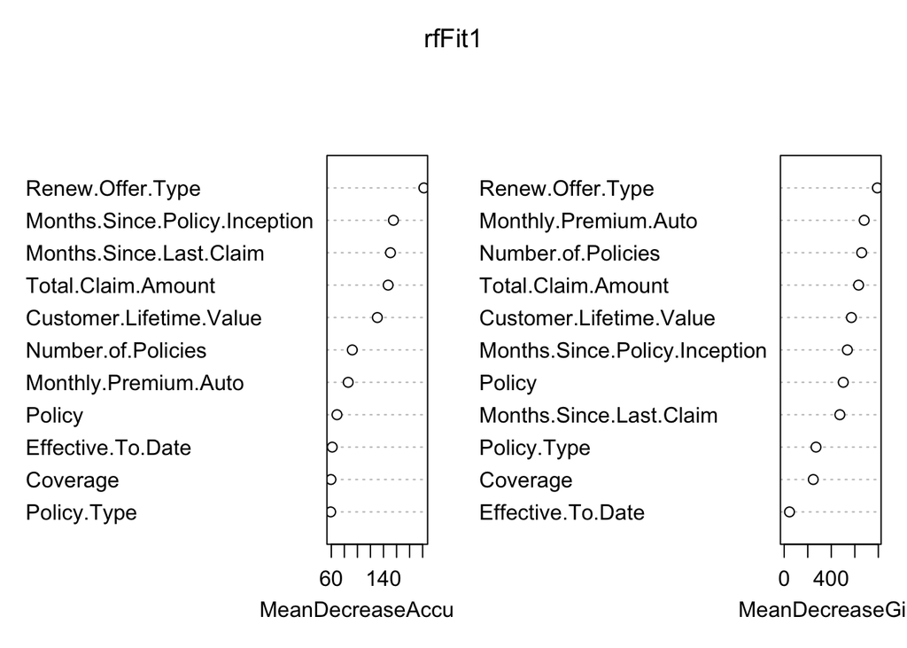

```r
varImpPlot(rfFit1)
```

The top 3 variables as infered from **Insurance profile** are 1. Renew Offer Type 2. Total Claim Amount 3. Customer Lifetime Value Although Months Since Last Claim and Months since policy Inception are of higher importance in accuracy, the importance in Gini is quite low and considering both the factors i think Total Claim Amount and Customer Lifetime Value are better. Additionally, this results are aline with those in our data exploration as we had also noted these 3 to be of some significance. Based on the explorations of the pilot data: 1. Renew Offer Type: The Offer 2 renew offers shows the most “Yes” `Response` distribution, while Offer 3 & 4 reported almost all `Response` “No”. Therefore, its impact to differentiate between the classes is significant. 2. Total Claim Amount: When value increases beyond a threshold of about 1500, all `Response` becomes “No”. Therefore, its impact to differentiate between the classes is significant. 3. Customer Lifetime Value: When value increases beyond a threshold of about 40000, all `Response` becomes “No”. Therefore, its impact to differentiate between the classes is significant.

In conclusion, in order to entice cutomers to have a “Yes” `Response`, the company could alter the renew offer type of the new product to the Offer 2 Type and eliminate the option of Offer Type 3 and 4, as the customers finds Offer 2 Type renewal as the most appealing. This might be due to the terms being less binding or demanding. Additionally, the company can shift its focus of audience to one where the customer profile indicates that they do not already have a long standing insurance plan with the company. This is due to the fact that if the customer already hits lifetime value of a threshold, they are less inclined to change policies. This is also supported by the fact that if the total claim amount is higher than 1500, the customer will already have a a certain loyality and faith in the product he/she is using and is less inclined to want to change.

```r
# Rank feature based on importance in the model
importance(rfFit2)
```

```
##                                 No        Yes MeanDecreaseAccuracy
## State                     199.9885  13.362703             170.5619
## Education                 188.5350 113.578446             214.0211
## EmploymentStatus          222.9264  -6.840361             223.4903
## Gender                    104.6772  61.524318             114.6190
## Income                    505.1922 141.892090             568.5646
## Location.Code             234.5207  88.158172             230.3827
## Marital.Status            241.3245 125.631032             252.6570
## Number.of.Open.Complaints 165.7404 144.608421             177.0553
## Sales.Channel             183.5038 120.734961             203.0777
## Vehicle.Class             172.8482 105.797360             192.9536
## Vehicle.Size              206.6490 108.470975             217.0227
##                           MeanDecreaseGini
## State                             356.8240
## Education                         371.7537
## EmploymentStatus                  771.9364
## Gender                            132.8247
## Income                           1917.9716
## Location.Code                     213.8136
## Marital.Status                    243.0222
## Number.of.Open.Complaints         473.4152
## Sales.Channel                     302.6781
## Vehicle.Class                     318.6760
## Vehicle.Size                      227.1999
```

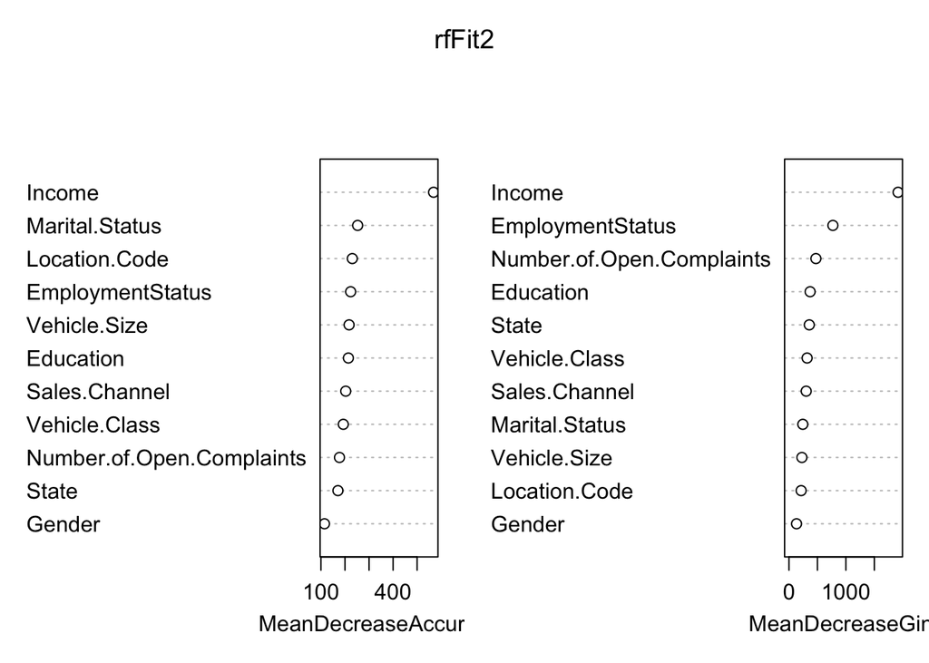

```r
varImpPlot(rfFit2)
```

In conclusion, in order to entice cutomers to have a “Yes” `Response`, the company focus its target audience to customer with sustainable income, as customer will be more likely to to have a “Yes” `Response` when they have spare cash to pay the premium. Additionally, the target audience should be highly educated customers as they are more aware of the benefits of having auto insurance and will tend to `Response` “Yes”. Lastly, company should organise roadshows where agents are able to approach a customer and provide a human touch when promoting the new product. Statistic have showed that the agents are able increase the likelyhood of a customer having a “Yes” `Response`.

Import the CSV data file `assign2_MarketPred.csv`. And use best model to predict values. Values of `Response` are stored in variables `P1` and `P2` for problem 1 and 2 respectively in a csv file `assign2_MarketPred_result.csv`.

```r
marketPred <- read.csv("assign2_marketPred.csv", header = TRUE)
library(lubridate)
a<-as.character(marketPred$Effective.To.Date)
b<-as.Date.character(a, format = "%m/%d/%y")

#transform data to month names
marketPred$Effective.To.Date <-month(b, label = TRUE)
marketPred$Effective.To.Date <- factor(marketPred$Effective.To.Date,
                             levels = c("Jan","Feb"),ordered = FALSE)
marketPred$Policy <- factor(marketPred$Policy, levels = levels(marketTrain$Policy))
p1<-predict(rfFit1, marketPred, type="class")
p2<-predict(rfFit2, marketPred, type="class")
marketPred$P1<-p1
marketPred$P2<-p2
write.csv(marketPred, "assign2_marketPred_result.csv")
```